# Week 7: Writing Functions & Lab 3

Joe Nese

University of Oregon  
Spring 2026

# Writing Functions & Lab 3

**Week 7**

## Agenda

- What makes functions “good”
- Building up functions
- Non-standard evaluation

**Learning objectives**

- Understand how functions build on top of each other and why “only do one thing” is a good mantra
- Understand non-standard evaluation is, even if you aren’t able to fully work with it

## Brainstorm

What makes a function “good” or “bad”

## Function Advice

- Your function should do ONE thing and do it well
- Embed useful error messages and warnings
  - Particularly if you’re working on a package or set of functions or others are using your functions
  - Right answer > Helpful error > Unhelpful error > Wrong answer
- Careful when naming functions - be as clear as possible
- Refactor your code to be more clear after initial drafts (it’s okay to be messy on a first draft)

## Refactoring Code

Improving the internal structure of your code to make it more readable, maintainable, and efficient, without changing its external behavior

- Make existing code
  - more readable
  - more maintainable
  - more modular
  - better performing
  - more efficient
- Maintain functionality

Breaking a function down into smaller functions

## Remember this from last week?

How can we break this function into smaller functions?

Brainstorm with your neighbor

```r
both_na <- function(x, y) {
    if(length(x) != length(y)) {
        lx <- length(x)
        ly <- length(y)

        v_lngths <- paste0("x = ", lx, ", y = ", ly)

        if(lx %% ly == 0 | ly %% lx == 0) {
            warning("Vectors were recycled (", v_lngths, ")")
        }
        else {
            stop("Vectors are of different lengths and are not recyclable:",
                 v_lngths)
        }
    }
    sum(is.na(x) & is.na(y))
}
```

## Calculate if recyclable

```r
recyclable <- function(x, y) {
    test1 <- length(x) %% length(y)
    test2 <- length(y) %% length(x)

    any(c(test1, test2) == 0)
}
```

## Test it

```r
a <- c(1, NA, NA, 3, 3, 9, NA)
b <- c(NA, 3, NA, 4, NA, NA, NA)
```

```r
recyclable(a, b)
```

```
[1] TRUE
```

```r
recyclable(a, c(b, b))
```

```
[1] TRUE
```

```r
recyclable(a, c(b, b, b))
```

```
[1] TRUE
```

```r
recyclable(c(a, a), c(b, b, b))
```

```
[1] FALSE
```

## Revision

```r
both_na <- function(x, y) {
    if(length(x) != length(y)) {
        lx <- length(x)
        ly <- length(y)

        v_lngths <- paste0("x = ", lx, ", y = ", ly)

        if(lx %% ly == 0 | ly %% lx == 0) {
            warning("Vectors were recycled (", v_lngths, ")")
        }
        else {
            stop("Vectors are of different lengths and are not recyclable:",
                 v_lngths)
        }
    }
    sum(is.na(x) & is.na(y))
}
```

```r
both_na <- function(x, y) {

    if(!recyclable(x, y)) {
        stop(
          "Vectors are of different lengths and are not recyclable:\n",
          "x = ", length(x), "\n",
          "y = ", length(y),
          call. = FALSE
      )
    }

    if(length(x) == length(y)) {
        return(sum(is.na(x) & is.na(y)))
    }

    if(recyclable(x, y)) {
        warning(
          "Vectors were recycled\n",
          "x = ", length(x), "\n",
          "y = ", length(y),
          call. = FALSE
      )
    }
  sum(is.na(x) & is.na(y))
}
```

## Test it

```r
both_na(a, b)
```

```
[1] 2
```

```r
both_na(a, c(b, b))
```

```
[1] 4
```

```r
both_na(c(a, a), b)
```

```
[1] 4
```

```r
both_na(c(a, b), c(b, b, b))
```

```
Error:
! Vectors are of different lengths and are not recyclable:
x = 14
y = 21
```

## Anything else?

Make errors/warnings a function

Note this function uses the `recylable()` function we created previously

```r
check_lengths <- function(x, y) {
    if(length(x) != length(y)) {
        if(recyclable(x, y)) {
          warning(
          "Vectors were recycled\n",
          "x = ", length(x), "\n",
          "y = ", length(y),
            call. = FALSE
          )
        }
        else {
          stop(
            "Vectors are of different lengths and are not recyclable:\n",
            "x = ", length(x), "\n",
            "y = ", length(y),
            call. = FALSE
          )
        }
    }
}
```

## Revision 2

Note `check_lengths()` contains `recyclable()`

```r
both_na <- function(x, y) {
    check_lengths(x, y)
    sum(is.na(x) & is.na(y))
}
```

## Test it

```r
both_na(a, b)
```

```
[1] 2
```

```r
both_na(a, c(b, b))
```

```
[1] 4
```

```r
both_na(c(a, a), b)
```

```
[1] 4
```

```r
both_na(c(a, b), c(b, b, b))
```

```
Error:
! Vectors are of different lengths and are not recyclable:
x = 14
y = 21
```

## Why would we do this?

- In this case - more readable code
- We might re-use the `recyclable()` or `check_lengths()` functions in other/new functions
- Helps make de-bugging easier

## Quick de-bugging example

Nested functions

```r
fx_clean <- function(x) {
  as.numeric(str_trim(as.character(x)))
}

fx_validate <- function(y) {
  if (any(is.na(y))){
    stop("NAs produced after coercion", call. = FALSE)
  }
  if (any(y < 0)) {
    stop("negative values not allowed", call. = FALSE)
  }
  y
}

fx_transform  <- function(z) {
  z <- log(z); z[!is.infinite(z)]
  }

fx_summarize  <- function(t) {
  mean(t) + 10
}

process_nested <- function(x) {
  y <- fx_clean(x)
  z <- fx_validate(y)
  t <- fx_transform(z)
  fx_summarize(t)
}
```

One big function

```r
process_big <- function(x) {
  # clean
  x <- str_trim(as.character(x))
  y <- as.numeric(x)

  # validate
  if (any(is.na(y))) {
    stop("NAs produced after coercion", call. = FALSE)
  }
  if (any(y < 0)) {
    stop("negative values not allowed", call. = FALSE)
  }

  # transform
  z <- log(y)
  t <- z[!is.infinite(z)]

  # summarize
  mean(t) + 10
}
```

## `traceback()`

```r
vect <- c(1, 2, -3, 4)
```

Nested functions

```r
process_nested(vect)
traceback()
```

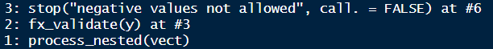

One big function

```r
process_big(vect)
traceback()
```

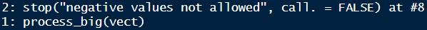

# Non-standard evaluation (NSE)

A high-level look

## Note

- Were it not for the `{tidyverse}`, we would’nt cover NSE
- Generally, it’s not an incredibly important topic
- But, NSE is ubiquitous in the `{tidyverse}` - literally just about everything uses NSE, which makes programming with `{tidyverse}` functions more difficult

## What is NSE

- Implementation of different scoping rules
- In `{dplyr}` and many others, arguments are evaluated inside the specified **data frames**, rather than the current or global **environment**

**How?**

1. Capture an expression (**quote it**)
2. Use the expression within the correct context (**evaluate it**)

For example:

`x` is evaluated as `df$x` rather than `globalenv()$x`

## Example

Using the `percentile_df()` function we created last week

- Last week
- Updated

We used `arg$x`

```r
percentile_df <- function(x) {
    arg <- as.list(match.call()) # returns a list of the arguments
    x <- sort(x)
    d <- data.frame(value = x, percentile = ecdf(x)(x))
    names(d)[1] <- paste0(as.character(arg$x), collapse = "_") # names first column after the argument
    d
}
percentile_df(rnorm(100, 5, 0.2)) |>
    head()
```

```
  rnorm_100_5_0.2 percentile
1        4.527487       0.01
2        4.534369       0.02
3        4.557970       0.03
4        4.598729       0.04
5        4.608676       0.05
6        4.634060       0.06
```

Here `base::substitute()`

```r
percentile_df <- function(x) {
    sorted <- sort(x)
    d <- data.frame(sorted, percentile = ecdf(sorted)(sorted))
    names(d)[1] <- paste0(substitute(x), collapse = "_")
    d
}
percentile_df(rnorm(100, 5, 0.2)) |>
    head()
```

```
  rnorm_100_5_0.2 percentile
1        4.474692       0.01
2        4.525117       0.02
3        4.570262       0.03
4        4.623991       0.04
5        4.692405       0.05
6        4.719494       0.06
```

## What does `substitute()` do?

- Outside of a function
  - operates just like `quote()` - it quotes the input
- Inside of a function
  - does as its name implies - it substitutes the input for the name

## Example

Outside of a function

```r
quote(subset(df, select = var))
```

```
subset(df, select = var)
```

```r
substitute(subset(df, select = var))
```

```
subset(df, select = var)
```

Inside of a function

```r
extract_var <- function(df, var) {
    substitute(df)
}
extract_var(mtcars)
```

```
mtcars
```

substitutes the input for the name

## Getting `extract_var()` to work

```r
extract_var <- function(df, var) {
    subset(eval(substitute(df)),
           select = var)
}
extract_var(mtcars, "mpg")
```

```
                     mpg
Mazda RX4           21.0
Mazda RX4 Wag       21.0
Datsun 710          22.8
Hornet 4 Drive      21.4
Hornet Sportabout   18.7
Valiant             18.1
Duster 360          14.3
Merc 240D           24.4
Merc 230            22.8
Merc 280            19.2
Merc 280C           17.8
Merc 450SE          16.4
Merc 450SL          17.3
Merc 450SLC         15.2
Cadillac Fleetwood  10.4
Lincoln Continental 10.4
Chrysler Imperial   14.7
Fiat 128            32.4
Honda Civic         30.4
Toyota Corolla      33.9
Toyota Corona       21.5
Dodge Challenger    15.5
AMC Javelin         15.2
Camaro Z28          13.3
Pontiac Firebird    19.2
Fiat X1-9           27.3
Porsche 914-2       26.0
Lotus Europa        30.4
Ford Pantera L      15.8
Ferrari Dino        19.7
Maserati Bora       15.0
Volvo 142E          21.4
```

Why `eval()`?

- `substitute()` is quoting the input, but we then need to `eval`uate it
- All of this is a little confusing, Joe!
- Well `{tidyverse}` uses this so frequently, they’ve implemented their own version
  - `tidyeval`, which we’ll get to in a minute

## Better

Use NSE for both arguments

Wrap `eval()` around both the `df` and the `var`

```r
extract_var <- function(df, var) {
    eval(substitute(var), envir = df)
}
extract_var(mtcars, mpg)
```

```
 [1] 21.0 21.0 22.8 21.4 18.7 18.1 14.3 24.4 22.8 19.2 17.8 16.4 17.3 15.2 10.4
[16] 10.4 14.7 32.4 30.4 33.9 21.5 15.5 15.2 13.3 19.2 27.3 26.0 30.4 15.8 19.7
[31] 15.0 21.4
```

- The above is equivalent to `df$var` but where both `df` and `var` can be swapped programmatically
- The `var` argument is being **substituted** in for whatever the user supplies, and is being **evaluated** within the `df` *environment*

## Maybe more simply

```r
extract_var <- function(df, var) {
    df[, as.character(substitute(var))]
}
extract_var(mtcars, mpg)
```

```
 [1] 21.0 21.0 22.8 21.4 18.7 18.1 14.3 24.4 22.8 19.2 17.8 16.4 17.3 15.2 10.4
[16] 10.4 14.7 32.4 30.4 33.9 21.5 15.5 15.2 13.3 19.2 27.3 26.0 30.4 15.8 19.7
[31] 15.0 21.4
```

- Why `as.character()`?
  - `substitute(var)` won’t return the string “`mpg`”, it returns the name
  - it will try to evaluate the name by looking for an object called “`mpg`” in your environment

## Taking this even further

```r
extract_vars <- function(df, ...) {
  vars <- substitute(alist(...))
  df[, as.character(vars)[-1]]
}
extract_vars(mtcars, mpg, cyl, disp) |> head()
```

```
                   mpg cyl disp
Mazda RX4         21.0   6  160
Mazda RX4 Wag     21.0   6  160
Datsun 710        22.8   4  108
Hornet 4 Drive    21.4   6  258
Hornet Sportabout 18.7   8  360
Valiant           18.1   6  225
```

- We’ve now basically replicated `dplyr::select()`
- Notice the use of `[-1]`, because calling `as.character()` on `vars` always returns `alist` as the first element in the vector

## Why is NSE used so frequently in the `{tidyverse}`?

Without NSE you’d write

```r
mpg[mpg$cyl == 6, c("cty", "hwy")]
```

```
# A tibble: 79 × 2
     cty   hwy
   <int> <int>
 1    16    26
 2    18    26
 3    18    27
 4    15    25
 5    17    25
 6    17    25
 7    15    25
 8    15    24
 9    17    25
10    18    26
# ℹ 69 more rows
```

With NSE and `{dplyr}`, you write

```r
mpg |>
  filter(cyl == 6) |>
  select(cty, hwy)
```

```
# A tibble: 79 × 2
     cty   hwy
   <int> <int>
 1    16    26
 2    18    26
 3    18    27
 4    15    25
 5    17    25
 6    17    25
 7    15    25
 8    15    24
 9    17    25
10    18    26
# ℹ 69 more rows
```

- `cyl`, `cty`, and `hwy` are not objects in your environment — they’re column names
- NSE lets `filter()` and `select()` capture those names and look them up inside the data frame

## Interactive work!

- It makes interactive work easier!
- **But** it make programming with these functions harder…
- Without NSE, `select()` and similar functions would not know where `cyl`, `cty`, and `hwy` “live”
- It would be looking for objects in the global environment with these names

## `{dplyr}` programming fail

- Let’s say we wanted a function that returned means in a nice table-like format for a variable by two groups (cross-tab sort of format)
- Typically, we would start by solving this problem for a single situation, then we’d generalize it to a function
- Let’s try it!

## `{dplyr}` programming fail

Try generalizing the code below into a function

```r
mtcars |>
  group_by(cyl, gear) |>
  summarize(mean = mean(mpg, na.rm = TRUE)) |>
  pivot_wider(
    names_from = cyl,
    values_from = mean
  )
```

```
# A tibble: 3 × 4
   gear   `4`   `6`   `8`
  <dbl> <dbl> <dbl> <dbl>
1     3  21.5  19.8  15.0
2     4  26.9  19.8  NA
3     5  28.2  19.7  15.4
```

## Generalize to a function

Typically, we would expect something like this to work

```r
group_means <- function(data, group_1, group_2, outcome) {
  data |>
    group_by(group_1, group_2) |>
    summarize(mean = mean(outcome, na.rm = TRUE)) |>
    pivot_wider(
      names_from = group_1,
      values_from = mean)
}
```

## But it doesn’t work

```r
group_means(mtcars, mpg, cyl, gear)
```

```
Error in `group_by()`:
! Must group by variables found in `.data`.
Column `group_1` is not found.
Column `group_2` is not found.
```

```r
group_means(diamonds, price, cut, clarity)
```

```
Error in `group_by()`:
! Must group by variables found in `.data`.
Column `group_1` is not found.
Column `group_2` is not found.
```

## Why?

It’s looking for objects called `group_1` and `group_2` that don’t exist inside the function or in the global workspace!

**Solution**

tidyeval!

## Tidy evaluation (`{rlang}`)

- `{tidyverse}` doesn’t use `substitute()` and `eval()` directly
- `{tidyverse}` has its own system called tidyeval, built in the `{rlang}` package
- tidyeval captures an expression **AND** the environment it came from, so it evaluates correctly even when passed in functions

embrace the `{{}}` curly-curly operator

## Curly-curly

```r
group_means3 <- function(data, group_1, group_2, outcome) {
      data |>
            group_by({{group_1}}, {{group_2}}) |>
            summarize(mean = mean({{outcome}}, na.rm = TRUE)) |>
            pivot_wider(
              names_from = {{group_1}},
              values_from = mean)
}

group_means3(mtcars, cyl, gear, mpg)
```

```
# A tibble: 3 × 4
   gear   `4`   `6`   `8`
  <dbl> <dbl> <dbl> <dbl>
1     3  21.5  19.8  15.0
2     4  26.9  19.8  NA
3     5  28.2  19.7  15.4
```

## Pipe-centric

Because the `data` argument comes first, this function works just like any other in the `tidyverse`

```r
diamonds |>
  filter(color == "E") |>
  select(carat, cut, clarity) |>
  group_means3(cut, clarity, carat)
```

```
# A tibble: 8 × 6
  clarity   Fair  Good `Very Good` Premium Ideal
  <ord>    <dbl> <dbl>       <dbl>   <dbl> <dbl>
1 I1       0.969 1.33        1.07    1.04  1.04
2 SI2      1.02  0.883       0.930   0.958 0.874
3 SI1      0.867 0.724       0.723   0.726 0.671
4 VS2      0.690 0.739       0.664   0.619 0.521
5 VS1      0.633 0.681       0.610   0.643 0.504
6 VVS2     0.601 0.560       0.427   0.512 0.484
7 VVS1     0.64  0.418       0.400   0.462 0.427
8 IF      NA     0.373       0.579   0.576 0.458
```

## Note

- `{{}}` syntax gets you out of tidyeval complications most of the time
- If you start doing a lot of programming with the `{tidyverse}`, you’ll probably want to read up more on [tidyeval](https://ggplot2.tidyverse.org/reference/tidyeval.html) and get comfy with quoting/unquoting

## Pass the dots!

- If you have a specific variable that is used in an expression use `{{var}}`
- But if you have multiple variables being passed through untouched, then pass the dots and use `...`

## Specific variable `{{}}`

For example:

`filter()` needs to know what the specific `col` is

```r
my_filter <- function(df, col) {
  dplyr::filter(df, {{col}} > 10)
}
```

## Passing variables through with `...`

Say we want to write a function that summarizes selected columns of a data frame by returning:

- mean
- standard deviation
- min
- max

Of course we would solve on an example case first, then generalize to a function

## Try it out

Want to try it on your own?

1. Start with the `diamonds` data
2. Select few columns
3. Return a df like this:

```
# A tibble: 3 × 5
  var       mean       sd   min      max
  <chr>    <dbl>    <dbl> <dbl>    <dbl>
1 carat    0.798    0.474   0.2     5.01
2 depth   61.7      1.43   43      79
3 price 3933.    3989.    326   18823
```

## Try it out

Want to try it on your own?

```r
diamonds |>
  select(carat, depth, price) |>
  pivot_longer(
    cols = everything(),
    names_to = "var",
    values_to = "val"
  ) |>
    group_by(var) |>
    summarize(
      mean = mean(val, na.rm = TRUE),
      sd = sd(val, na.rm = TRUE),
      min = min(val, na.rm = TRUE),
      max = max(val, na.rm = TRUE)
     )
```

```
# A tibble: 3 × 5
  var       mean       sd   min      max
  <chr>    <dbl>    <dbl> <dbl>    <dbl>
1 carat    0.798    0.474   0.2     5.01
2 depth   61.7      1.43   43      79
3 price 3933.    3989.    326   18823
```

## Pass the dots!

```r
summarize_cols <- function(data, ...) {
    data |>
        select(...) |>
        pivot_longer(
          cols = everything(),
          names_to = "var",
          values_to = "val"
        ) |>
        group_by(var) |>
        summarize(
          mean = mean(val, na.rm = TRUE),
        sd = sd(val, na.rm = TRUE),
        min = min(val, na.rm = TRUE),
        max = max(val, na.rm = TRUE)
        )
}
```

```r
summarize_cols(diamonds, depth, table, price)
```

```
# A tibble: 3 × 5
  var     mean      sd   min   max
  <chr>  <dbl>   <dbl> <dbl> <dbl>
1 depth   61.7    1.43    43    79
2 price 3933.  3989.     326 18823
3 table   57.5    2.23    43    95
```

## Pipe-centric again

Just putting data as the first argument leads to a lot of benefits

```r
library(palmerpenguins)
penguins |>
  select_if(is.numeric) |>
  summarize_cols(everything())
```

```
# A tibble: 5 × 5
  var                 mean      sd    min    max
  <chr>              <dbl>   <dbl>  <dbl>  <dbl>
1 bill_depth_mm       17.2   1.97    13.1   21.5
2 bill_length_mm      43.9   5.46    32.1   59.6
3 body_mass_g       4202.  802.    2700   6300
4 flipper_length_mm  201.   14.1    172    231
5 year              2008.    0.818 2007   2009
```

## Example with plotting

Linearity

- We want to look and see if an x/y relation is linear
- Function should show linear and non-linear relations
- Optionally show the data

## Maybe this?

```r
check_linear <- function(data, x, y, points = FALSE, se = TRUE) {

  p <- ggplot(data, aes(x, y))

  if(isTRUE(points)) {
    p <- p + geom_point(color = "gray80")
  }

  if(isTRUE(se)) {
    p <- p +
      geom_smooth(method = "lm") +
      geom_smooth()
  } else {
    p <- p +
      geom_smooth(method = "lm", se = FALSE) +
      geom_smooth(se = FALSE)
  }
  p
}
```

## Nope

```r
check_linear(penguins, bill_length_mm, bill_depth_mm)
```

```
Error in `geom_smooth()`:
! Problem while computing aesthetics.
ℹ Error occurred in the 1st layer.
Caused by error:
! object 'bill_length_mm' not found
```

## This

- Use tidyeval
- Also could pass the dots for `se =` to make it more concise

```r
check_linear <- function(data, x, y, points = FALSE, ...) {

  p <- ggplot(data, aes({{x}}, {{y}}))

  if (points) {
      p <- p + geom_point(color = "gray80")
    }

  p +
      geom_smooth(method = "lm",
                    color = "magenta",
                      ...) +
      geom_smooth(...)
}
```

## Default

```r
check_linear(penguins, bill_length_mm, bill_depth_mm)
```

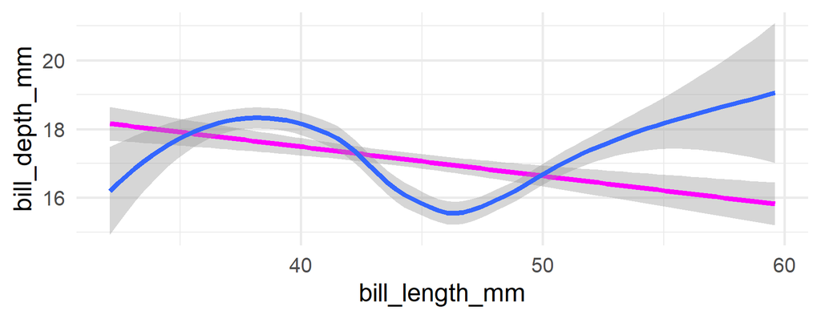

## Add points

```r
check_linear(penguins, bill_length_mm, bill_depth_mm,
             points = TRUE)
```

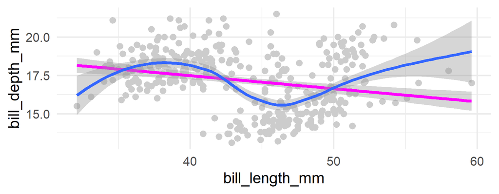

## Add any `ggplot()` functions

```r
check_linear(mtcars, disp, mpg, se = FALSE) +
    labs(title = "Checking linearity",
         subtitle = "Linear vs LOESS fits",
         x = "Engine Displacement",
         y = "Miles Per gallon") +
    theme_dark(22)
```

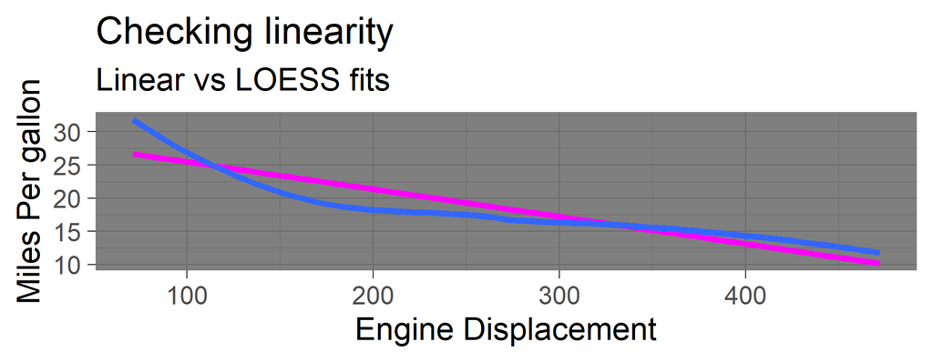

## Building up plots

- Let’s create a function that calculates means and standard errors for every numeric column in a data frame
- We’ll then use this function to create a plotting function

## Means and *SE*’s

- First figure it out for a single example
- Note there’s not built-in function for the standard error of the mean, which is $\frac{\sigma}{\sqrt{n}}$

```r
# SE function
se <- function(x) {
  x <- x[!is.na(x)] # remove missing data
  sd(x) / sqrt(length(x))
}
```

## Full means and *SE*s

Very similar to our `summarize_cols()` function

```r
penguins |>
  select_if(is.numeric) |>
  pivot_longer(everything(),
               names_to = "var",
               values_to = "val") |>
  group_by(var) |>
  summarize(
    mean = mean(val, na.rm = TRUE),
    se = se(val)
  )
```

```
# A tibble: 5 × 3
  var                 mean      se
  <chr>              <dbl>   <dbl>
1 bill_depth_mm       17.2  0.107
2 bill_length_mm      43.9  0.295
3 body_mass_g       4202.  43.4
4 flipper_length_mm  201.   0.760
5 year              2008.   0.0441
```

## Challenge

Try to generalize the code on the previous slide into a function

Test it on the `forcats::gss_cat` data

## Translate to a function

```r
estimate_means <- function(df) {
  df |>
    select_if(is.numeric) |>
    pivot_longer(everything(),
                 names_to = "var",
                 values_to = "val") |>
    group_by(var) |>
    summarize(mean = mean(val, na.rm = TRUE),
              se = se(val))
}
estimate_means(forcats::gss_cat)
```

```
# A tibble: 3 × 3
  var        mean     se
  <chr>     <dbl>  <dbl>
1 age       47.2  0.118
2 tvhours    2.98 0.0243
3 year    2007.   0.0304
```

## Plot

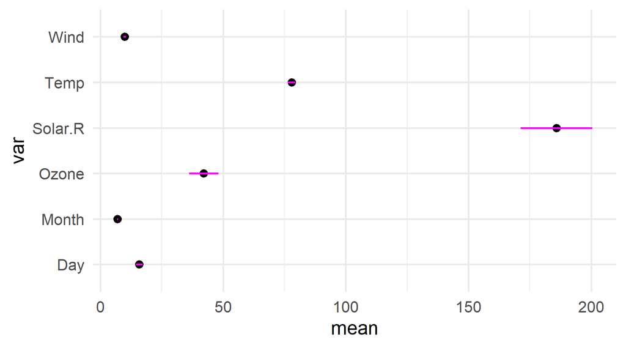

```r
estimate_means(airquality) |>
  ggplot(aes(mean, var)) +
    geom_point() +
    geom_linerange(
        aes(xmin = mean + (qnorm(0.025) * se),
            xmax = mean + (qnorm(0.975) * se)),
        color = "magenta",
    )
```

## Create plot function

Notice we’ve successfully avoided tideval entirely in both examples!

```r
plot_means <- function(df) {
  means <- estimate_means(df) |>
    mutate(var = reorder(factor(var), mean))

  ggplot(means, aes(mean, var)) +
    geom_point() +
    geom_linerange(
      aes(xmin = mean + (qnorm(0.025) * se),
          xmax = mean + (qnorm(0.975) * se)),
      color = "magenta",
    )
}
```

## Examples

```r
plot_means(penguins)
```

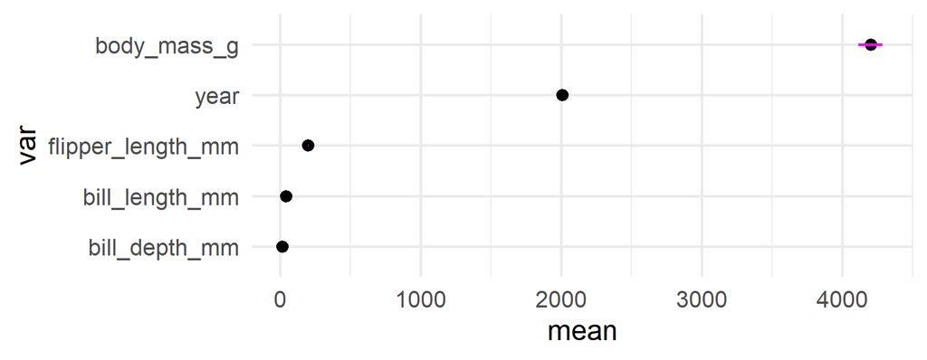

## Examples

```r
plot_means(diamonds)
```

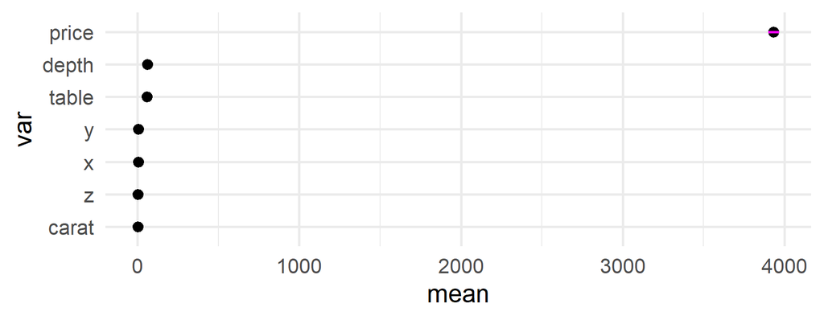

## Overall takeaway

- Non-standard evaluation is confusing but kind of neat
- Programming with the `{tidyverse}` can be a bit more difficult, but not always
  - use the `{{}}`
- Good to think about multiple ways to approach the same problem (and when programming, perhaps think outside the `{tidyverse}` at times)

# Lab 3